# Practical Machine Learning Course Project

Edmund Tran

January 30, 2016

The goal of this project is to predict how well someone is doing a barbell lift based on accelerometer data. We first read in the training and test set:

```r
trainset <- read.csv("pml-training.csv")
testset <- read.csv("pml-testing.csv")
```

Taking a look at the data, it seems that it is sorted by classe, a variable that acts as the “grade” for how well the participant is performing the exercise. There are 160 variables total, so I decided to run a summary to get a sense of the predictors:

```r
summary(trainset)

#1 to 7: ID features
#8 to 11: good
#12 to 36: missing data
#37 to 49: good
#50 to 59: missing data
#60 to 68: good
#69 to 83: missing data
#84 to 86: good
#87 to 101: missing data
#102: good
#103-112: missing data
#113-124: good
#125-139: missing data
#140: good
#141-150: missing data
#152-159: good
#160: OUTCOME
```

It seems like there were 19216 observations that were missing data on many of the variables. Since they represent so much of the sample, I decided to exclude the predictors that were NA or 0 for these observations.

```r
train2 <- trainset[,c(8:11,37:49,60:68,84:86,102,113:124,140,152:159,160)]
#str(train2)
```

I was still left with 51 predictors, which is a lot, so I decided to see if any had low variation or were highly correlated with each other. There were a few of the latter type, so I whittled down the list of predictors a little more.

```r
library(caret)
x = nearZeroVar(train2, saveMetrics = TRUE)
x[x[,"zeroVar"] + x[,"nzv"] > 0, ]
```

```
## [1] freqRatio     percentUnique zeroVar       nzv
## <0 rows> (or 0-length row.names)
```

```r
findCorrelation(cor(train2[,-52]))
```

```
## [1] 10  1  9  8 31 33 18
```

```r
train3 <- train2[,-findCorrelation(cor(train2[,-52]))]
```

First I tried to fit a tree model using k-fold cross-validation:

```r
# k-fold
folds <- createFolds(y = train3$classe, k = 5, list = TRUE, returnTrain = TRUE)

# tree model
library(rpart)
library(rattle)
accuracy <- NULL
for (i in 1:5) {
  tree <- train(classe ~ ., data = train3[folds[[i]],], preProcess=c("center", "scale"), method = "rpart")
  prediction <- predict(tree, newdata = train3[-folds[[i]],])
  accuracy[[i]] <- confusionMatrix(data = prediction, reference = train3[-folds[[i]],]$classe)$overall[1]
}
accuracy
```

```
## [1] 0.4913354 0.4901861 0.4984717 0.4978344 0.4933741
```

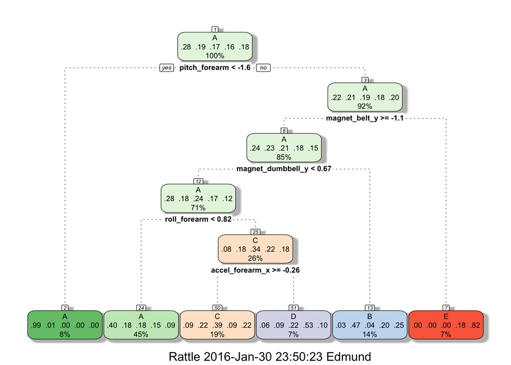

```r
rattle::fancyRpartPlot(tree$finalModel)
```

As you can see, the accuracy was not great. But maybe the predictors it uses are especially significant, so I tried to use random forests with those five predictors on one of the folds. It was taking a long time to compute, so I researched random forest compute times and it seems like running this algorithm on over 10,000 observations is not a good idea.

```r
# trying again with a few hundred observations instead
trainsample <- sample(1:19622, 500)
rftrain <- train3[trainsample[1:300],]
rftest <- train3[trainsample[401:500],]
rfFit <- train(classe ~ pitch_forearm + magnet_belt_y + magnet_dumbbell_y + roll_forearm + accel_forearm_x, data = rftrain, method = "rf", prox=TRUE)
```

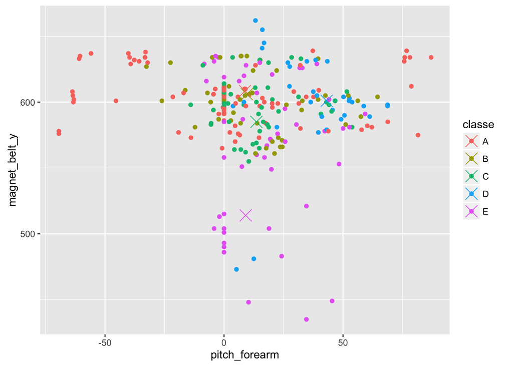

```r
#for plotting cluster centers
clusterP <- classCenter(rftrain[,c("pitch_forearm", "magnet_belt_y")], rftrain$classe, rfFit$finalModel$prox)
clusterP <- as.data.frame(clusterP)
clusterP$classe <- rownames(clusterP)

library(ggplot2)
p <- qplot(pitch_forearm, magnet_belt_y, col=classe, data = rftrain)
p + geom_point(aes(x=pitch_forearm, y=magnet_belt_y, col=classe),size=5, shape=4, data=clusterP)
```

```r
predrf <- predict(rfFit, rftest)
table(predrf, rftest$classe)
```

```
##
## predrf  A  B  C  D  E
##      A 25  3  5  1  1
##      B  0 16  3  0  4
##      C  2  3  8  1  2
##      D  1  1  0 11  1
##      E  0  0  0  1 11
```

```r
rfFit2 <- train(classe ~ ., data = rftrain, method = "rf", prox=TRUE)
predrf2 <- predict(rfFit2, rftest)
table(predrf2, rftest$classe)
```

```
##
## predrf2  A  B  C  D  E
##       A 27  5  2  1  0
##       B  0 17  0  0  3
##       C  1  1 14  1  2
##       D  0  0  0 12  0
##       E  0  0  0  0 14
```

```r
predrf3 <- predict(rfFit2, testset)
predrf3
```

[output not shown]